# Why the central-tendency gate rests on the CLT, not on residual normality

Reference note for visStatistics (not part of the package vignette)

Sabine Schilling

2026-06-01

> **Purpose.** A personal record of the argument behind `visstat()`’s central-tendency gate, with the runnable code and the output figures in one place. The runnable script is `dev/clt_mean_demo.R`; the Type I companion is `inst/appendix_typeI_simulation.R`. This file is a reference note, **not** the package vignette.

# 1 The claim

The residual-normality test (Shapiro–Wilk / Anderson–Darling) inspects the **wrong object**. Inference on group means in the general linear model — the estimated coefficients $\hat\beta$ — relies on the **sampling distribution of the mean** being normal, not on the residuals being normal. The central limit theorem (CLT) normalises the former and never the latter when the data-generating distribution is skewed or heavy-tailed.

## 1.1 The argument, in the author’s words

1. tests of glm family assume normal errors
2. if the function they come from is highly skewed, the residuals will never be normal “enough” -> fall back to non-parametric methods
3. role of clt: it assumes that when the group numbers go to infinity, the DISTRIBUTION of the mean, in the glm the estimated bs become normal
4. For simulation studies one must sample out of a skewed function and plot the distribution of the means, not the residuals, they should be normal
5. the threshold will always be dependent of the exact distribution shape, described by skew and kurtosis roughly. thus every threshold is arbitrary!!!

## 1.2 The same chain, expanded

1. General linear model inference (the $t$/$F$ reference distributions) is exact when the **errors** $\varepsilon_i$ are normal. Residuals $e_i = y_i-\hat y_i$ only estimate the errors.
2. If the data come from a highly skewed function, the errors are skewed at **every** $n$; the residual sample mirrors that, so SW/AD reject — correctly — and routing falls back to a rank-based test.
3. The CLT acts on the **estimator**, not the errors: $\hat\beta=(X^\top X)^{-1}X^\top y$ is a linear combination of the $y_i$, so its sampling distribution $\to$ normal as $n\to\infty$ even while the errors stay skewed. For a one-way design $\hat\beta$ is just the group means.
4. The right thing to inspect is therefore the sampling distribution of the **mean**, not the residuals. That is what the simulations below plot.
5. The $n$ at which the mean is “normal enough” depends on the exact distribution shape (captured to leading order by skewness and kurtosis), so any fixed threshold is necessarily approximate.

# 2 The law: skew of the mean $\sim \gamma_1/\sqrt n$

This is not one named theorem. It is two **exact** moment identities, plus the expansion that uses them.

## 2.1 Exact part — cumulant additivity

For iid draws, cumulants of a sum add: $\kappa_r(S_n)=n\,\kappa_r(X)$ for $S_n=\sum_i X_i$. The mean is $\bar X = S_n/n$, so
$$\kappa_r(\bar
X)=\frac{\kappa_r(S_n)}{n^{\,r}}=\frac{\kappa_r(X)}{n^{\,r-1}}.$$
Substituting into skewness $\kappa_3/\kappa_2^{3/2}$ and excess kurtosis $\kappa_4/\kappa_2^{2}$:
$$\operatorname{skew}(\bar
X)=\frac{\kappa_3/n^2}{(\sigma^2/n)^{3/2}}=\frac{\gamma_1}{\sqrt n},
\qquad
\operatorname{exkurt}(\bar
X)=\frac{\kappa_4/n^3}{(\sigma^2/n)^{2}}=\frac{\gamma_2}{n}.$$
These are **exact**, not asymptotic. Averaging $n$ iid values divides the third cumulant by an extra $n$ and the fourth by an extra $n^2$, while the variance drops only by $n$ — hence skewness fades as $1/\sqrt n$ and excess kurtosis a full order faster, as $1/n$.

## 2.2 Edgeworth expansion — the shape

The same cumulants give the shape of the standardised mean $Z_n=\sqrt n(\bar X-\mu)/\sigma$:
$$f_{Z_n}(x)\approx\phi(x)\Big[1+\tfrac{\gamma_1}{6\sqrt
n}He_3(x)
+\tfrac{\gamma_2}{24\,n}He_4(x)+\dots\Big].$$
The $1/\sqrt n$ on the skew term and $1/n$ on the kurtosis term are exactly the cumulant orders above.

## 2.3 Berry–Esseen — the rigorous rate

$$\sup_x\bigl|F_{Z_n}(x)-\Phi(x)\bigr|\le
\frac{C\,\rho}{\sigma^3\sqrt n},
\qquad \rho=E|X-\mu|^3.$$
Guarantees the CLT for any finite-third-moment distribution and pins the rate at $1/\sqrt n$, with the leading constant scaling with skewness.

**Consequence.** A fixed per-group threshold can never be right for all shapes: the $n$ you need scales with $\gamma_1^2$. Income-level skew ($\gamma_1\approx6$) needs $n\gtrsim 3600$ to get the mean’s skew under $0.1$.

# 3 Simulations

Monte Carlo **illustrates** specific distributions; it is not a proof (a proof would need every finite-moment distribution). The exact moment law above is the general statement. Each table below should show the empirical skew/kurtosis of the mean sitting on the predicted $\gamma_1/\sqrt n$ and $\gamma_2/n$.

```r
## Load the machinery from the runnable script WITHOUT triggering its auto-run.
options(clt_demo_defs_only = TRUE)
source("clt_mean_demo.R")
```

## 3.1 A. Heavy tails, modest skew — the mean normalises

```r
invisible(do.call(run_clt_demo, SCENARIOS$johnson))
```

```
##
## === Johnson SU: skew 2, heavy tails  ->  mean ~normal by n = 50-100 ===
## Base distribution: skewness = 2.06, excess kurtosis = 22.9
## Sampling distribution of the standardised mean (40000 groups per n)
##     n |  emp.skew  g1/sqrt(n) |  emp.exkurt    g2/n
##    50 |    0.251     0.291   |     0.333    0.458
##   100 |    0.189     0.206   |     0.227    0.229
##   500 |    0.082     0.092   |     0.067    0.046
##  1000 |    0.064     0.065   |     0.085    0.023
```

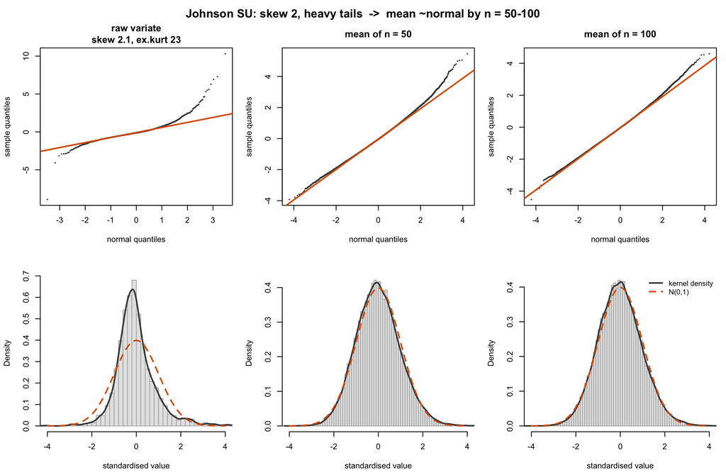

## 3.2 B. Income (lognormal) — extreme skew, the mean does NOT normalise

Lognormal$(0,1)$, the textbook income shape, skewness $\approx 6$. The mean’s skew is $\gamma_1/\sqrt{50}\approx0.85$ at $n=50$ and still $\approx0.2$ at $n=1000$ — visibly non-normal across the whole 50–100 range.

```r
invisible(do.call(run_clt_demo, SCENARIOS$income))
```

```
##
## === Lognormal (income): extreme skew  ->  mean still skewed at n = 50-100 ===
## Base distribution: skewness = 5.99, excess kurtosis = 90.7
## Sampling distribution of the standardised mean (40000 groups per n)
##     n |  emp.skew  g1/sqrt(n) |  emp.exkurt    g2/n
##    50 |    0.824     0.848   |     1.726    1.814
##   100 |    0.581     0.599   |     0.835    0.907
##   500 |    0.261     0.268   |     0.195    0.181
##  1000 |    0.199     0.190   |     0.144    0.091
```

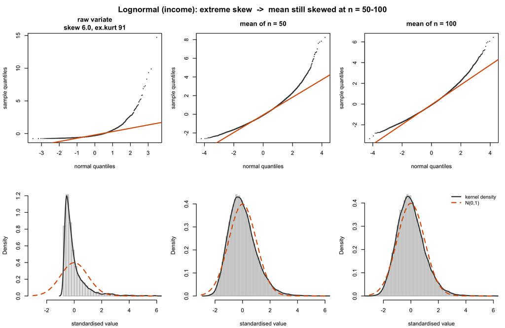